# TP d’introduction au SBM

Vanesse Labeyrie & Sarah Ouadah

Vendredi après-midi 14 Juin 2019

Durée du TP : 3h

# Données d’échanges de semences à Kabururu

```r
rm(list=ls())
load('../data/Kabururu_data.Rdata')
ls()
```

```
## [1] "kabururu_bin_adjacency" "kabururu_bin_igraph"
## [3] "nodeVar"
```

- $156$ individus interrogés
- “kabururu_bin_adjacency”: matrice d’adjacence binaire des échanges entre individus ($1$ si au moins un échange, $0$ sinon)
- “kabururu_bin_igraph : objet igraph du réseau d’échanges
- “nodeVar” : attributs décrivant les individus (ferme, noms des donneurs et receveurs, dialecte, âge, sexe et clan)

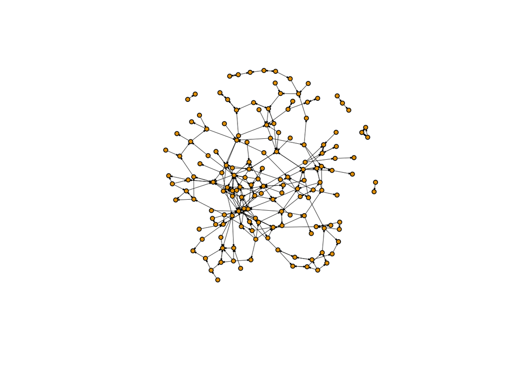

# Packages utilisés

- Le package R blockmodels pour l’inférence du modèle à blocs stochastiques [SBM] pour les réseaux d’échanges
- Les packages igraph et ggplot2 pour des représentations graphiques.

```r
library(blockmodels)
library(igraph)
library(ggplot2)
```

- Pour cette classe, nous avons écrit des fonctions ad-hoc supplémentaires. Elles se trouvent dans ce fichier :

```r
source('function_for_blockmodels.R')
```

# Modèle à blocs stochastique pour un réseau binaire

On considère que deux individus sont en interaction s’ils ont effectués au moins un échange, c’est-à-dire donné ou reçu des semences.

Représentation de la matrice d’adjacence :

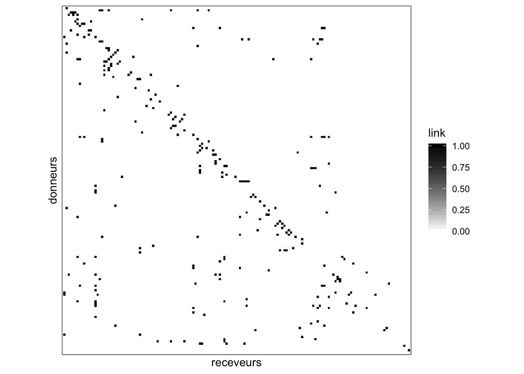

```r
plotMatrix(Mat = kabururu_bin_adjacency,rowFG = 'donneurs', colFG  = 'receveurs')
```

## Modèle et inférence

$$\begin{align*}
(Z_i) \text{ i.i.d.} \qquad & Z_i \sim \mathcal{M}(1, \pi) \\
(Y_{ij}) \text{ indep.} \mid (Z_i) \qquad & (Y_{ij} \mid Z_i=k, Z_j = \ell) \sim \mathcal{B}(\alpha_{k\ell})
\end{align*}$$

- Pour commencer, on définit l’objet

```r
sbm.kabururu_bin <- BM_bernoulli("SBM",kabururu_bin_adjacency)
```

Lorsque la matrice d’adjacence est symétrique (graphe non dirigé), “SBM_sym”" remplace “SBM”; il est important de l’indiquer pour des raisons statistiques.

- On applique ensuite la méthode d’inférence

```r
sbm.kabururu_bin$estimate()
```

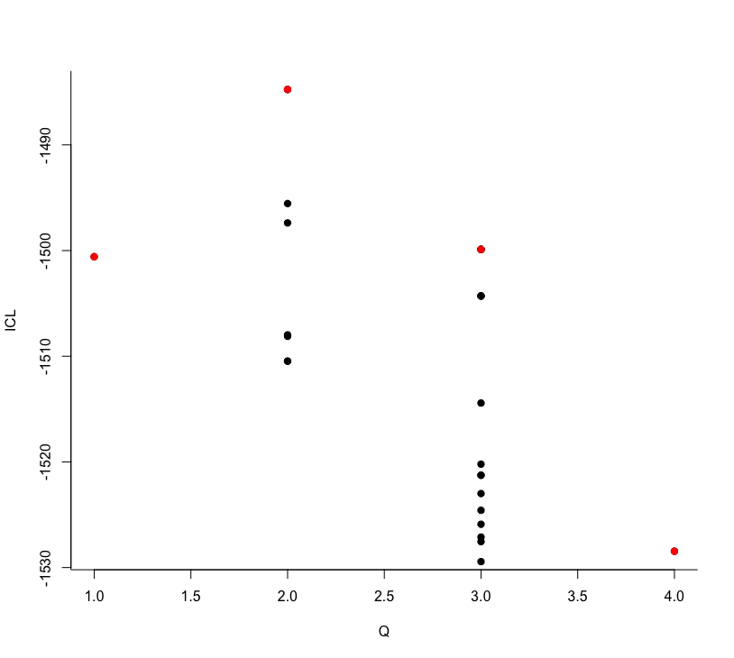

- Les différents points correspondent à plusieurs runs d’estimation (résultant en une valeur de critère de sélection de modèle) pour un nombre donné de groupes (noté $Q$ ici).
- On sélectionne le meilleur nombre de groupe (au vu du critère ICL).

```r
Q = which.max(sbm.kabururu_bin$ICL)
Q
```

```
## [1] 2
```

- On peut maintenant extraire les paramètres d’intérêt, c’est-à-dire ($\alpha$, $\pi$) et les attributions de groupes aux individus:

```r
paramEstimSBM <- extractParamBM(sbm.kabururu_bin,Q)
paramEstimSBM$pi
```

```
## [1] 0.3120351 0.6879649
```

```r
paramEstimSBM$alpha
```

```
##             [,1]        [,2]
## [1,] 0.044189847 0.001186486
## [2,] 0.002729046 0.013131733
```

```r
paramEstimSBM$Z
```

```
##   [1] 2 2 1 1 1 1 1 1 1 1 1 1 1 1 1 2 2 2 2 2 2 2 2 1 2 2 2 2 2 2 2 2 2 2 2
##  [36] 2 2 2 2 2 2 2 2 2 2 2 2 2 2 2 2 2 2 2 2 2 2 2 1 2 2 2 2 2 2 2 2 2 1 1
##  [71] 1 2 1 2 2 2 2 2 1 1 1 2 1 1 2 2 2 2 2 2 2 2 2 2 1 2 2 2 2 2 2 2 2 2 2
## [106] 2 2 2 2 2 2 1 1 1 1 1 1 1 2 1 1 2 2 2 2 1 1 1 2 2 1 1 1 1 1 1 1 1 2 1
## [141] 2 1 1 1 2 2 2 2 2 1 2 2 2 2 2 2
```

- On peut représenter :

la matrice d’adjacence réorganisée selon le regroupement.

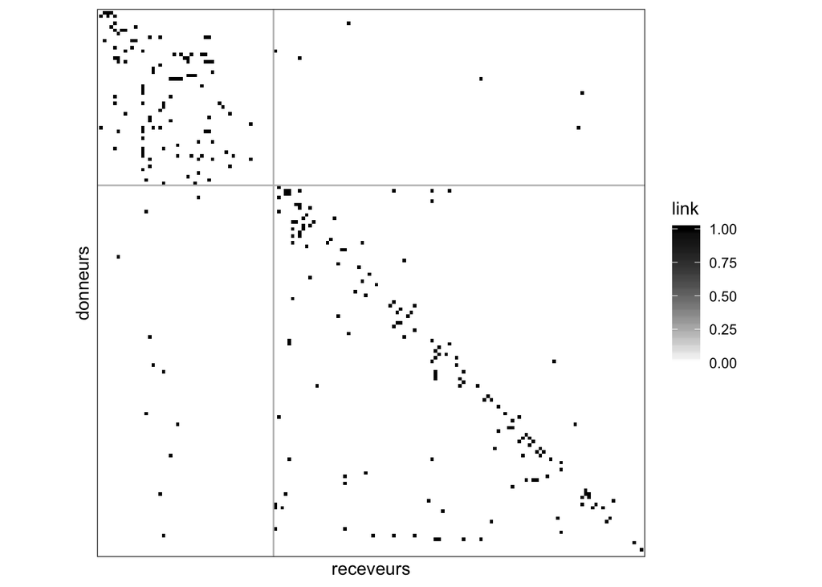

```r
plotMatrix(kabururu_bin_adjacency,'donneurs', 'receveurs', fileNameSave = NULL, clustering = list(row=paramEstimSBM$Z))
```

le réseau avec les noeuds colorés selon leur groupe d’appartenance

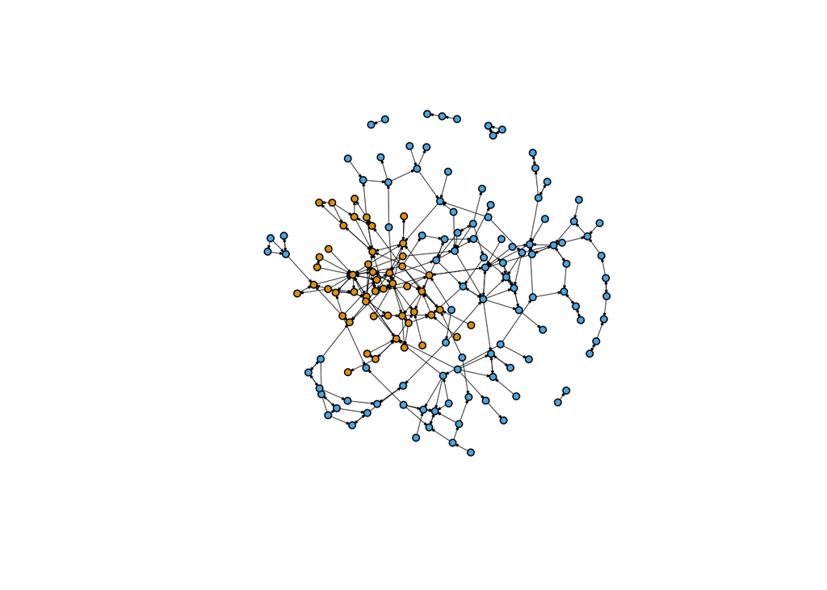

une vue globale du réseau selon les groupes.

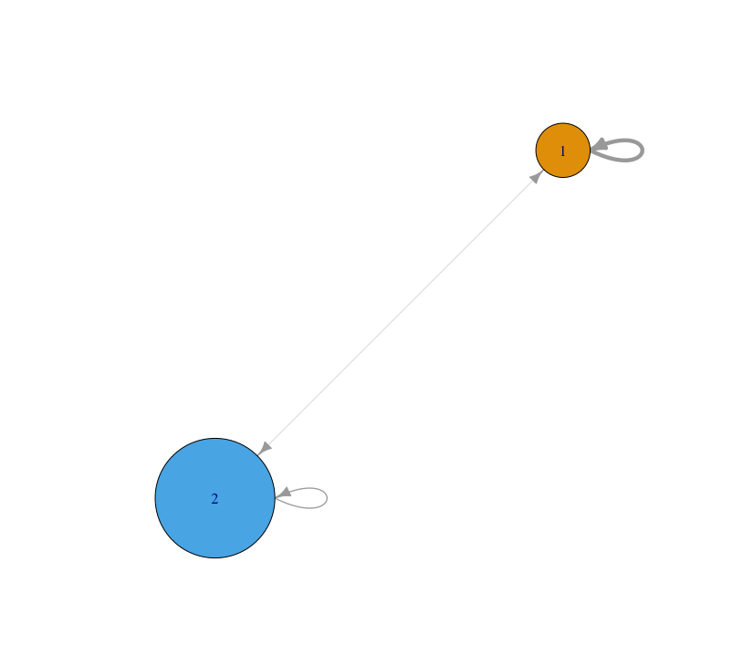

```r
G <- graph_from_adjacency_matrix(paramEstimSBM$alpha, mode = c("directed"), weighted = TRUE, diag = TRUE)
plot.igraph(G,vertex.size=paramEstimSBM$pi*100,edge.width=abs(E(G)$weight)*3,vertex.color=1:Q, layout=layout_nicely)
```

- La composition des groupes est donnée par :

```r
lapply(1:Q,function(q){nodeVar$name1[paramEstimSBM$Z == q]})
```

```
## [[1]]
##  [1] JANE       NANCY      PURITY     SUSAN      EDITH      NICETA
##  [7] MAGARET    PHILICILA  JOYCE      GRACE      JENIFFER   SAMUEL
## [13] MARY       ESTHER     HELLEN     SPIRA      NJERU      EVANGELINE
## [19] AGNES      CATHERINE  ANGELINA   AROISIA    LUCY       SILVESTHER
## [25] ANASTACIA  EDITH      NAHASON    NYAGA      CATHERINE  ROSALINE
## [31] BIRIBINA   GRACE      ALICE      IRENE      JOHN       MANDRIS
## [37] PAUL       SELESIO    SARAH      NANCY      CATHERINE  DOROTHY
## [43] JOHN       DIONICIA   ALBERT     PAMELA     JOTHAM     LEONARD
## [49] ESIACIA    ESTHER
## 362 Levels:  ABIGAELI ABISAGE ABISAGI ABIZAGI AGNES ALBERT ALBETA ... ZIPPORAH
##
## [[2]]
##   [1] AGNES     TENERUSHA BENASIA   ENYESIA   LUCYLINE  AGNES     JOSEPHAT
##   [8] AUCILIA   ALICE     MILLICAH  ENICIA    JANE      HELLEN    HELLEN
##  [15] LYDIA     LUCYLINE  LUCY      STELLA    MARGARET  EMILIE    HELLEN
##  [22] JANE      PURITY    JULIET    FLORANCE  NANCY     MARGARET  PHILICILA
##  [29] SARA      JUDITH    ABIGAELI  SUSAN     JOHN      ELOSY     WINFRED
##  [36] ISAAC     REBECCA   JULIANA   TANITHA   NAHASHON  RAELI     JAMES
##  [43] ELIUD     DEFATHER  CECILIA   JESSICA   ELIZABETH JANE      ISABELLE
##  [50] JUDITH    LUCY      JUDY      BEATRICE  TERESIA   ALIPILATA AGNES
##  [57] BONFACE   AUSILIA   CATHERINE IRENE     JAMES     NDINGO    JENECIA
##  [64] SABELIO   EVELYN    JAMES     JENECIA   EVELYN    NICELA    NANCY
##  [71] BIATRICE  BIRIBINA  FRIDA     CECILIA   GRACE     JAPHET    SAMUEL
##  [78] JOSEPH    JOSPHAT   MARY      ANASIALIA STEPHANO  NEWTON    CATHERINE
##  [85] MARY      ALBERT    CHARLES   DOROTHY   JERINA    CATHERINE ROSE
##  [92] REGINA    FAITH     MAGDALINE FRIDA     ELIAS     JAMLICK   ESTHER
##  [99] JUDITH    JASTUS    ESTER     LYNETTE   ALEXANDER PERIS     WINFRED
## [106] LENITY
## 362 Levels:  ABIGAELI ABISAGE ABISAGI ABIZAGI AGNES ALBERT ALBETA ... ZIPPORAH
```

- On peut maintenant caractériser les groupes au vu des attributs décrivant les individus (dialecte, âge, sexe et clan) :

```r
names(nodeVar)
```

```
##  [1] "ods"        "Id"         "Label"      "farm"       "name1"
##  [6] "name2"      "ntora"      "dialect"    "birth"      "sex"
## [11] "clan"       "ntora_pple" "col"
```

```r
lapply(1:Q,function(q){table(nodeVar$dialect[paramEstimSBM$Z == q])})
```

```
## [[1]]
##
##  CH  MB OTH  TH
##  29  11   1   9
##
## [[2]]
##
##  CH  MB OTH  TH
##  44  29   1  32
```

```r
lapply(1:Q,function(q){table(nodeVar$sex[paramEstimSBM$Z == q])})
```

```
## [[1]]
##
##  F  M
## 40 10
##
## [[2]]
##
##  F  M
## 85 20
```

```r
sum(is.na(nodeVar$birth))
```

```
## [1] 42
```

```r
sum(is.na(nodeVar$clan))
```

```
## [1] 47
```